# Processos INAR (1)

Author

Paulo Manoel da Silva Junior

# Processo INAR (1)

**Objetivo**

- Utilizar procesos INAR (1), tendo como base três distribuições diferentes no termo aleatório do erro. E em nosso presente estudo as distribuições são **Poisson, Binomial Negativa e Geométrica.**
- Utilizar o operador `thinning binomial`, que utiliza da distribuição binomial.
- A forma do processo pode ser vista da seguinte forma:

$$Y_t = \alpha \hspace{0.2cm} \circ \hspace{0.2cm} Y_{t-1} \hspace{0.2cm} + \hspace{0.2cm} \epsilon_t$$

Em que o operador $\alpha \hspace{0.2cm} \circ = \sum_{i=1}^{Y} N_i$

- Vamos fazer algumas simulações de séries e testar as estimativas dos parâmetros, através de dois métodos: Mínimos quadrados condicionais e Máxima Verossimilhança Condicional.
- Após a estimativa dos parâmetros vamos simular a série com os parâmetros estimados e comparar com a série verdadeira, e no final vamos utilizar uma série de valores de contagem real (do mundo prático), e submeter aos métodos para observar qual se adequará melhor aos meus dados.
- `Observação:` Na utilização das distribuições binomial negativa e geométrica utilizaremos ambas parametrizadas pela média, no caso da distribuição binomial negativa, ela será parametrizada por $\mu$ e por $\sigma^2$.

**Bibliotecas**

- De início utilizarei apenas poucas bibliotecas.
- `optimx`: Utilizada para maximizar a função de log verossimilhança na estimativa dos parâmetros
- `DataExplorer`: Utilizado para fazer a estatística Descritiva da Série Temporal
- `dygraphs`: Plotar a série temporal
- `plotly`: Outra biblioteca para plotar a série temporal
- `skimr`: Estatística Descritiva da Série Temporal, seja as simuladas ou conjunto de dados reais
- Criaremos aqui em blocos as funções de simular a série temporal, com base nas distribuições, bem como a de estimar usando mínimos quadrados condicionais e máxima verossimilhança condicional.

**Simular Série**

```r
simular_poisson <- function(n, alpha, lambda){
  x <- numeric(n)
  x[1] <- rpois(1, lambda)

  for(t in 2:n){
    thinnig_binomial <- rbinom(1, x[t-1], alpha)
    erro <- rpois(1, lambda)
    x[t] <- thinnig_binomial + erro
  }
  return(x)
}

simular_binomial_negativa <- function(n, alpha, mu, sigma2){
  x <- numeric(n)
  r <- mu^2 / (sigma2 - mu)
  p <- mu / sigma2
  x[1] <- rnbinom(1, size = r, prob = p)

  for (t in 2:n) {
    thinning_binomial <- rbinom(1, x[t-1], alpha)
    erro <- rnbinom(1, size = r, prob = p)
    x[t] <- thinning_binomial + erro
  }
  return(x)
}

simular_geometrica <- function(n, alpha, mu){
  x <- numeric(n)
  p <- 1 / (1 + mu)
  x[1] <- rgeom(1, p)

  for (t in 2:n) {
    thinning_binomial <- rbinom(1, x[t-1], alpha)
    erro <- rgeom(1, p)
    x[t] <- thinning_binomial + erro
  }
  return(x)
}
```

**Mínimos Quadrados Condicionais**

```r
minimos_quadrados <- function(x){
  n <- length(x)
  S1 <- sum(x[-1] * x[-n])                                  # Soma de Y_t * Y_{t-1}
  S2 <- sum(x[-n]^2)                                        # Soma de Y_{t-1}^2
  S3 <- sum(x[-1])                                          # Soma de Y_t
  S4 <- sum(x[-n])                                          # Soma de Y_{t-1}

  # Estimado de alpha

  alpha_hat <- (S1 - (S3 * S4) / (n-1)) / (S2 - (S4^2) / (n-1))
  alpha_hat <- max(0, min(alpha_hat, 1)) # Por definição sabemos que alpha pertence ao intervalo [0,1]

  lambda_hat <- (S3 - alpha_hat * S4) / (n-1)
  lambda_hat <- max(0, lambda_hat) # Como valores de contagem são positivos, temos que definir esse intervalo

  return(c(alpha_estimado = alpha_hat, lambda_estimado = lambda_hat))
}
```

**Máxima Verossimilhança Condicional**

```r
logveros_poisson <- function(parametros, x){
  alpha <- parametros[1]
  lambda <- parametros[2]
  n <- length(x)
  log_lik <- 0

  for(t in 2:n){
    probabilidade <- 0
    for (k in 0:min(x[t], x[t-1])) {
      probabilidade <- probabilidade + dbinom(k, x[t-1], alpha) * dpois(x[t] - k, lambda)
    }
    log_lik <- log_lik + log(probabilidade)
  }
  return(-log_lik)
}

estimar_max_ver_poisson <- function(x){
  chutes <- c(alpha = 0.4, lambda = mean(x))

  resultado <- optimx(
    par = chutes,
    fn = logveros_poisson,
    x = x,
    method = "L-BFGS-B",
    lower = c(0, 0),
    upper = c(1, Inf)
  )
  return(c(alpha = resultado$alpha, lambda = resultado$lambda))
}

logveros_binomial_negativa <- function(parametros, x){
  alpha <- parametros[1]
  mu <- parametros[2]
  sigma2 <- parametros[3]

  r <- mu^2 / (sigma2 - mu)
  p <- mu / sigma2
  n <- length(x)
  log_lik <- 0

  for (t in 2:n) {
    probabilidade <- 0
    for (k in 0:min(x[t], x[t-1])) {
      probabilidade <- probabilidade + dbinom(k, x[t-1], alpha) * dnbinom(x[t] - k , size = r, prob = p)
    }
    log_lik <- log_lik + log(probabilidade)
  }
  return(-log_lik)
}

estimar_max_ver_binomial_negativa <- function(x){
  chutes <- c(alpha = 0.4, mu = mean(x), sigma2 = var(x))

  resultado <- optimx(
    par = chutes,
    fn = logveros_binomial_negativa,
    x = x,
    method = "L-BFGS-B",
    lower = c(0, 0, 0),
    upper = c(1, Inf, Inf)
  )
  return(c(alpha = resultado$alpha, mu = resultado$mu, sigma = resultado$sigma2))
}

logveros_geometrica <- function(parametros, x){
  alpha <- parametros[1]
  mu <- parametros[2]
  n <- length(x)
  p <- 1 / (1 + mu)
  log_lik <- 0

  for(t in 2:n){
    probabilidade <- 0
    for (k in 0:min(x[t], x[t-1])) {
      probabilidade <- probabilidade + dbinom(k, x[t-1], alpha) * dgeom(x[t] - k, p)
    }
    log_lik <- log_lik + log(probabilidade)
  }
  return(-log_lik)
}

estimar_max_ver_geometrica <- function(x){
  chutes <- c(alpha = 0.4, mu = mean(x))

  resultado <- optimx(
    par = chutes,
    fn = logveros_geometrica,
    x = x,
    method = "L-BFGS-B",
    lower = c(0, 0),
    upper = c(1, Inf)
  )
  return(c(alpha = resultado$alpha, mu = resultado$mu))
}
```

## Simulações

- Vamos simular as séries de tamanhos variados e com as distribuições variadas, sendo variada também as distribuições que usaremos

`Observação:` Na primeira simulação, vou considerar séries de tamanho 100, com um $\alpha$ = 0.7 e com $\lambda$ = 2, no caso da binomial negativa, que temos $\sigma^2$ = 4.

```r
set.seed(2025)
alpha_verdadeiro <- 0.7
lambda_verdadeiro <- 2
n <- 100
serie_poisson_100 <- simular_poisson(n, alpha = alpha_verdadeiro, lambda = lambda_verdadeiro)
serie_geometrica_100 <- simular_geometrica(n, alpha = alpha_verdadeiro, mu = lambda_verdadeiro)
serie_binomial_negativa_100 <- simular_binomial_negativa(n, alpha = alpha_verdadeiro, mu = lambda_verdadeiro, sigma2 = 4)
```

Vamos usar os mesmos parâmetros, vamos apenas aumentar o tamanho da série para 150

```r
serie_poisson_150 <- simular_poisson(n = 150, alpha = alpha_verdadeiro, lambda = lambda_verdadeiro)
serie_geometrica_150 <- simular_geometrica(n = 150, alpha = alpha_verdadeiro, mu = lambda_verdadeiro)
serie_binomial_negativa_150 <- simular_binomial_negativa(n = 150, alpha = alpha_verdadeiro, mu = lambda_verdadeiro, sigma2 = 4)
```

Aumentando para 200

```r
serie_poisson_200 <- simular_poisson(n = 200, alpha = alpha_verdadeiro, lambda = lambda_verdadeiro)
serie_geometrica_200 <- simular_geometrica(n = 200, alpha = alpha_verdadeiro, mu = lambda_verdadeiro)
serie_binomial_negativa_200 <- simular_binomial_negativa(n = 200, alpha = alpha_verdadeiro, mu = lambda_verdadeiro, sigma2 = 4)
```

**Visualizando as séries**

**Tamanho 100**

```r
poisson_100 <- ts(serie_poisson_100)
binomial_negativa_100 <- ts(serie_binomial_negativa_100)
geometrica_100 <- ts(serie_geometrica_100)

series_100 <- cbind(poisson_100, binomial_negativa_100, geometrica_100)
colnames(series_100) <- c("Poisson", "Binomial Negativa", "Geometrica")

dygraph(series_100, main = "Visulização das Séries Temporais de Tamanho 100") %>%
  dySeries("Poisson", label = "Poisson", drawPoints = TRUE, pointSize = 3) %>%
  dySeries("Binomial Negativa", label = "Binomial Negativa", drawPoints = TRUE, pointSize = 3) %>%
  dySeries("Geometrica", label = "Geométrica", drawPoints = TRUE, pointSize = 3 )
```

[interactive chart not shown]

**Tamanho 150**

```r
poisson_150 <- ts(serie_poisson_150)
binomial_negativa_150 <- ts(serie_binomial_negativa_150)
geometrica_150 <- ts(serie_geometrica_150)

series_150 <- cbind(poisson_150, binomial_negativa_150, geometrica_150)
colnames(series_150) <- c("Poisson", "Binomial Negativa", "Geometrica")

dygraph(series_150, main = "Visualização da Série Temporal de tamanho 150") %>%
  dySeries("Poisson", label = "Poisson", drawPoints = TRUE, pointSize = 3) %>%
  dySeries("Binomial Negativa", label = "Binomial Negativa", drawPoints = TRUE, pointSize = 3) %>%
  dySeries("Geometrica", label = "Geométrica", drawPoints = TRUE, pointSize = 3)
```

[interactive chart not shown]

**Tamanho 200**

```r
poisson_200 <- ts(serie_poisson_200)
binomial_negativa_200 <- ts(serie_binomial_negativa_200)
geometrica_200 <- ts(serie_geometrica_200)

series_200 <- cbind(poisson_200, binomial_negativa_200, geometrica_200)
colnames(series_200) <- c("Poisson", "Binomial Negativa", "Geometrica")

dygraph(series_200, main = "Visualização da Série Temporal de tamanho 200") %>%
  dySeries("Poisson", label = "Poisson", drawPoints = TRUE, pointSize = 3) %>%
  dySeries("Binomial Negativa", label = "Binomial Negativa", drawPoints = TRUE, pointSize = 3) %>%
  dySeries("Geometrica", label = "Geométrica", drawPoints = TRUE, pointSize = 3)
```

[interactive chart not shown]

## Estimando os parâmetros

Vamos estimar os parâmetros e após isso simular a série usando os parâmetros estimados para observar o desempenhos dos métodos.

```r
min_quad_poi_100 <- minimos_quadrados(serie_poisson_100)
min_quad_bin_negativa_100 <- minimos_quadrados(serie_binomial_negativa_100)
min_quad_geometrica_100 <- minimos_quadrados(serie_geometrica_100)


min_quad_poi_150 <- minimos_quadrados(serie_poisson_150)
min_quad_bin_negativa_150 <- minimos_quadrados(serie_binomial_negativa_150)
min_quad_geometrica_150 <- minimos_quadrados(serie_geometrica_150)

min_quad_poi_200 <- minimos_quadrados(serie_poisson_200)
min_quad_bin_negativa_200 <- minimos_quadrados(serie_binomial_negativa_200)
min_quad_geometrica_200 <- minimos_quadrados(serie_geometrica_200)
```

```r
max_vero_poisson_100 <- estimar_max_ver_poisson(serie_poisson_100)
max_vero_bin_nega_100 <- estimar_max_ver_binomial_negativa(serie_binomial_negativa_100)
max_vero_geom_100 <- estimar_max_ver_geometrica(serie_geometrica_100)
```

```r
max_vero_poisson_150 <- estimar_max_ver_poisson(serie_poisson_150)
max_vero_bin_nega_150 <- estimar_max_ver_binomial_negativa(serie_binomial_negativa_150)
max_vero_geom_150 <- estimar_max_ver_geometrica(serie_geometrica_150)
```

```r
max_vero_poisson_200 <- estimar_max_ver_poisson(serie_poisson_200)
max_vero_bin_nega_200 <- estimar_max_ver_binomial_negativa(serie_binomial_negativa_200)
max_vero_geom_200 <- estimar_max_ver_geometrica(serie_geometrica_200)
```

- Simulação de Monte Carlo
- Fazer a simulação gerando 5.000 séries diferentes

```r
simulacao_monte_carlo <- function(n_simulacoes, n_amostra, alpha_verdadeiro, mu_verdadeiro, sigma_verdadeiro, distribuicao){

  variavel <- ifelse(distribuicao %in% c("poisson", "geometrica"), 2, 3)
  resultados_CLS <- matrix(NA, nrow = n_simulacoes, ncol = 2)
  resultados_CML <- matrix(NA, nrow = n_simulacoes, ncol = variavel)

  if(distribuicao == "poisson"){
    for (i in 1:n_simulacoes) {
      x <- simular_poisson(n = n_amostra, alpha = alpha_verdadeiro, lambda = mu_verdadeiro)

      resultados_CLS[i, ] <- minimos_quadrados(x)

      resultados_CML[i, ] <- estimar_max_ver_poisson(x)
    }
  }
  if(distribuicao == "binomial"){
    for (i in 1:n_simulacoes) {
      x <- simular_binomial_negativa(n = n_amostra, alpha = alpha_verdadeiro, mu = mu_verdadeiro, sigma2 = sigma_verdadeiro)
      resultados_CLS[i, ] <- minimos_quadrados(x)

      resultados_CML[i, ] <- estimar_max_ver_binomial_negativa(x)
    }
  }
  if(distribuicao == "geometrica"){
    for (i in 1:n_simulacoes) {

      x <- simular_geometrica(n = n_amostra, alpha = alpha_verdadeiro, mu = mu_verdadeiro)

      resultados_CLS[i, ] <- minimos_quadrados(x)
      resultados_CML[i, ] <- estimar_max_ver_geometrica(x)

    }
  }

  media_CLS <- colMeans(resultados_CLS, na.rm = T)
  variancia_CLS <- apply(resultados_CLS, 2, var, na.rm = T)

  media_CML <- colMeans(resultados_CML, na.rm = T)
  variancia_CML <- apply(resultados_CML, 2, var, na.rm = T)

  return(list(
    media_Minimos_Quadrados_condicionais = media_CLS,
    variancia_Minimos_Quadrados_condicionais = variancia_CLS,
    media_Maxima_verossimilhanca_condicional = media_CML,
    variancia_Maxima_verossimilhanca_condicional = variancia_CML,
    minimos_quadrados_resultado <- resultados_CLS,
    maxima_verossimilhanca_resultado <- resultados_CML
  ))
}
```

## Simulações

Aqui, inicialmente a primeira simulação teremos os seguintes valores de $\alpha = 0.6$ e $\lambda = 4$, e distribuição `Geométrica`.

### Amostra de tamanho 50

```r
resultados_geom_50 <- simulacao_monte_carlo(n_simulacoes = 5000, n_amostra = 50, alpha_verdadeiro = 0.6, mu_verdadeiro = 4, distribuicao = "geometrica")
```

```r
paste0("Com tamanho de amostra 50 e via mínimos quadrados condicionais, temos o seguinte alpha médio: ", round(resultados_geom_50$media_Minimos_Quadrados_condicionais[1], 4)," para o lambda Médio: ", round(resultados_geom_50$media_Minimos_Quadrados_condicionais[2], 4))
```

```
[1] "Com tamanho de amostra 50 e via mínimos quadrados condicionais, temos o seguinte alpha médio: 0.5451 para o lambda Médio: 4.5356"
```

```r
paste0("Com tamanho de amostra 50 e via Máxima Verossimilhança Condicional, temos o seguinte alpha médio: ",   round(resultados_geom_50$media_Maxima_verossimilhanca_condicional[1], 4)," para o lambda Médio: ", round(resultados_geom_50$media_Maxima_verossimilhanca_condicional[2], 4))
```

```
[1] "Com tamanho de amostra 50 e via Máxima Verossimilhança Condicional, temos o seguinte alpha médio: 0.5953 para o lambda Médio: 4.0678"
```

```r
paste0("Com tamanho de amostra 50 e via Mínimos Quadrados Condicionais, temos a variância do alpha: ",
       round(resultados_geom_50$variancia_Minimos_Quadrados_condicionais[1], 4), " e a variância para o lambda: ",
       round(resultados_geom_50$variancia_Minimos_Quadrados_condicionais[2], 4))
```

```
[1] "Com tamanho de amostra 50 e via Mínimos Quadrados Condicionais, temos a variância do alpha: 0.0136 e a variância para o lambda: 1.824"
```

```r
paste0("Com tamanho de amostra 50 e via Máxima Verossimilhança Condicional, temos a variância do alpha: ",
       round(resultados_geom_50$variancia_Maxima_verossimilhanca_condicional[1], 4), " e a variância para o lambda: ",
       round(resultados_geom_50$variancia_Maxima_verossimilhanca_condicional[2], 4))
```

```
[1] "Com tamanho de amostra 50 e via Máxima Verossimilhança Condicional, temos a variância do alpha: 0.0018 e a variância para o lambda: 0.4701"
```

```r
banco_geom_50_min_quad <- as.data.frame(resultados_geom_50[[5]])
banco_geom_50_max_vero <- as.data.frame(resultados_geom_50[[6]])
```

- Visualizando os resultados de Maneira Gráfica
- Através de um histograma, podemos analisar quais foram os resultados da estimação dos parâmetros.

```r
grafico_50_min_quad_lambda <- ggplot(banco_geom_50_min_quad) +
 aes(x = V2) +
 geom_histogram(aes(y = ..density..), bins = 60L, fill = "#46B47A", color = "black") +
 geom_density(
 fill = "gray", alpha = 0.5) +
 labs(x = "lambda", y = "Quantidade", title = "Histograma da Estimação de lambda com tamanho de amostra 50",
      subtitle = "Via Mínimos Quadrados Condicionais") +
 theme_classic() +
 theme(plot.title = element_text(size = 12L, hjust = 0.5))
```

```r
grafico_50_min_quad_alpha <- ggplot(banco_geom_50_min_quad) +
 aes(x = V1) +
 geom_histogram(aes(y = ..density..), bins = 60L, fill = "#46B47A", color = "black") +
 geom_density(
 alpha = 0.5, fill = "gray") +
 labs(x = "Alpha", y = "Quantidade", title = "Histograma da Estimação de Alpha com tamanho de amostra 50",
      subtitle = "Via Mínimos Quadrados Condicionais") +
 theme_classic() +
 theme(plot.title = element_text(size = 12L, hjust = 0.5))
```

```r
grafico_50_max_vero_lambda <- ggplot(banco_geom_50_max_vero) +
 aes(x = V2) +
 geom_histogram(aes(y = ..density..), bins = 60L, fill = "#46B47A", color = "black") +
 geom_density(
 alpha = 0.5, fill = "gray") +
 labs(x = "lambda", y = "Quantidade", title = "Histograma da Estimação de lambda com tamanho de amostra 50",
      subtitle = "Via Máxima Verossimilhança Condicional") +
 theme_classic() +
 theme(plot.title = element_text(size = 12L, hjust = 0.5))
```

```r
grafico_50_max_vero_alpha <- ggplot(banco_geom_50_max_vero) +
 aes(x = V1) +
 geom_histogram(aes(y = ..density..), bins = 60L, fill = "#46B47A", color = "black") +
 geom_density(
 alpha = 0.5, fill = "gray") +
 labs(x = "Alpha", y = "Quantidade", title = "Histograma da Estimação de Alpha com tamanho de amostra 50",
      subtitle = "Via Máxima Verossimilhança Condicional") +
 theme_classic() +
 theme(plot.title = element_text(size = 12L, hjust = 0.5))
```

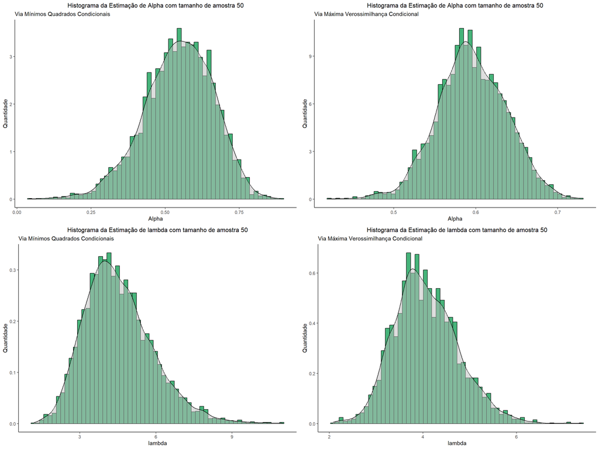

```r
gridExtra::grid.arrange(grafico_50_min_quad_alpha, grafico_50_max_vero_alpha, grafico_50_min_quad_lambda, grafico_50_max_vero_lambda, nrow = 2, ncol = 2)
```

### Amostra de tamanho 100

```r
resultados_geom_100 <- simulacao_monte_carlo(n_simulacoes = 5000, n_amostra = 100, alpha_verdadeiro = 0.6, mu_verdadeiro = 4, distribuicao = "geometrica")
```

```r
paste0("Com tamanho de amostra 100 e via mínimos quadrados condicionais, temos o seguinte alpha médio: ", round(resultados_geom_100$media_Minimos_Quadrados_condicionais[1], 4)," para o lambda Médio: ", round(resultados_geom_100$media_Minimos_Quadrados_condicionais[2], 4))
```

```
[1] "Com tamanho de amostra 100 e via mínimos quadrados condicionais, temos o seguinte alpha médio: 0.5712 para o lambda Médio: 4.2801"
```

```r
paste0("Com tamanho de amostra 100 e via Máxima Verossimilhança Condicional, temos o seguinte alpha médio: ",   round(resultados_geom_100$media_Maxima_verossimilhanca_condicional[1], 4)," para o lambda Médio: ", round(resultados_geom_100$media_Maxima_verossimilhanca_condicional[2], 4))
```

```
[1] "Com tamanho de amostra 100 e via Máxima Verossimilhança Condicional, temos o seguinte alpha médio: 0.5928 para o lambda Médio: 4.0768"
```

```r
paste0("Com tamanho de amostra 100 e via Mínimos Quadrados Condicionais, temos a variância do alpha: ",
       round(resultados_geom_100$variancia_Minimos_Quadrados_condicionais[1], 4), " e a variância para o lambda: ",
       round(resultados_geom_100$variancia_Minimos_Quadrados_condicionais[2], 4))
```

```
[1] "Com tamanho de amostra 100 e via Mínimos Quadrados Condicionais, temos a variância do alpha: 0.0067 e a variância para o lambda: 0.8526"
```

```r
paste0("Com tamanho de amostra 100 e via Máxima Verossimilhança Condicional, temos a variância do alpha: ",
       round(resultados_geom_100$variancia_Maxima_verossimilhanca_condicional[1], 4), " e a variância para o lambda: ",
       round(resultados_geom_100$variancia_Maxima_verossimilhanca_condicional[2], 4))
```

```
[1] "Com tamanho de amostra 100 e via Máxima Verossimilhança Condicional, temos a variância do alpha: 9e-04 e a variância para o lambda: 0.2573"
```

```r
banco_geom_100_min_quad <- as.data.frame(resultados_geom_100[[5]])
banco_geom_100_max_vero <- as.data.frame(resultados_geom_100[[6]])
```

- Visualizando os resultados de Maneira Gráfica
- Através de um histograma, podemos analisar quais foram os resultados da estimação dos parâmetros.

```r
grafico_100_min_quad_lambda <- ggplot(banco_geom_100_min_quad) +
 aes(x = V2) +
 geom_histogram(aes(y = ..density..), bins = 60L, fill = "#46B47A", color = "black") +
 geom_density(
 alpha = 0.5, fill = "gray") +
 labs(x = "lambda", y = "Densidade", title = "Histograma da Estimação de lambda com tamanho de amostra 100",
      subtitle = "Via Mínimos Quadrados Condicionais") +
 theme_classic() +
 theme(plot.title = element_text(size = 12L, hjust = 0.5))
```

```r
grafico_100_min_quad_alpha <- ggplot(banco_geom_100_min_quad) +
 aes(x = V1) +
 geom_histogram(aes(y = ..density..), bins = 60L, fill = "#46B47A", color = "black") +
 geom_density(
 alpha = 0.5, fill = "gray") +
 labs(x = "Alpha", y = "Densidade", title = "Histograma da Estimação de Alpha com tamanho de amostra 100",
      subtitle = "Via Mínimos Quadrados Condicionais") +
 theme_classic() +
 theme(plot.title = element_text(size = 12L, hjust = 0.5))
```

```r
grafico_100_max_vero_lambda <- ggplot(banco_geom_100_max_vero) +
 aes(x = V2) +
 geom_histogram(aes(y = ..density..), bins = 60L, fill = "#46B47A", color = "black") +
 geom_density(
 alpha = 0.5, fill = "gray") +
 labs(x = "lambda", y = "Densidade", title = "Histograma da Estimação de lambda com tamanho de amostra 100",
      subtitle = "Via Máxima Verossimilhança Condicional") +
 theme_classic() +
 theme(plot.title = element_text(size = 12L, hjust = 0.5))
```

```r
grafico_100_max_vero_alpha <- ggplot(banco_geom_100_max_vero) +
 aes(x = V1) +
 geom_histogram(aes(y = ..density..), bins = 60L, fill = "#46B47A", color = "black") +
 geom_density(
 alpha = 0.5, fill = "gray") +
 labs(x = "Alpha", y = "Densidade", title = "Histograma da Estimação de Alpha com tamanho de amostra 100",
      subtitle = "Via Máxima Verossimilhança Condicional") +
 theme_classic() +
 theme(plot.title = element_text(size = 12L, hjust = 0.5))
```

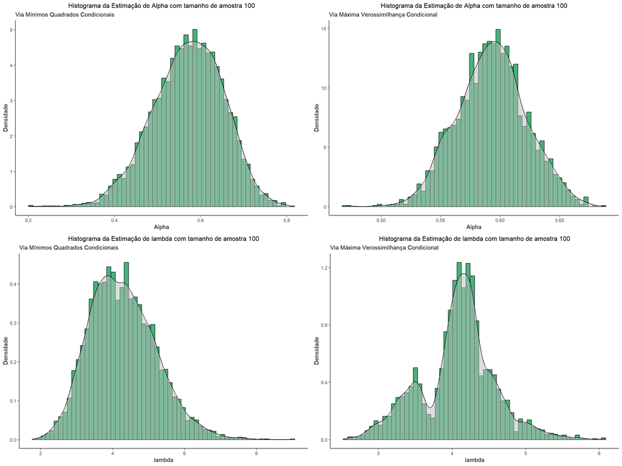

```r
gridExtra::grid.arrange(grafico_100_min_quad_alpha, grafico_100_max_vero_alpha, grafico_100_min_quad_lambda, grafico_100_max_vero_lambda, nrow = 2, ncol = 2)
```

### Amostra de tamanho 300

```r
resultados_geom_300 <- simulacao_monte_carlo(n_simulacoes = 5000, n_amostra = 300, alpha_verdadeiro = 0.6, mu_verdadeiro = 4, distribuicao = "geometrica")
```

```r
paste0("Com tamanho de amostra 300 e via mínimos quadrados condicionais, temos o seguinte alpha médio: ", round(resultados_geom_300$media_Minimos_Quadrados_condicionais[1], 4)," para o lambda Médio: ", round(resultados_geom_300$media_Minimos_Quadrados_condicionais[2], 4))
```

```
[1] "Com tamanho de amostra 300 e via mínimos quadrados condicionais, temos o seguinte alpha médio: 0.5909 para o lambda Médio: 4.0918"
```

```r
paste0("Com tamanho de amostra 300 e via Máxima Verossimilhança Condicional, temos o seguinte alpha médio: ",   round(resultados_geom_300$media_Maxima_verossimilhanca_condicional[1], 4)," para o lambda Médio: ", round(resultados_geom_300$media_Maxima_verossimilhanca_condicional[2], 4))
```

```
[1] "Com tamanho de amostra 300 e via Máxima Verossimilhança Condicional, temos o seguinte alpha médio: 0.6114 para o lambda Médio: 3.9755"
```

```r
paste0("Com tamanho de amostra 300 e via Mínimos Quadrados Condicionais, temos a variância do alpha: ",
       round(resultados_geom_300$variancia_Minimos_Quadrados_condicionais[1], 4), " e a variância para o lambda: ",
       round(resultados_geom_300$variancia_Minimos_Quadrados_condicionais[2], 4))
```

```
[1] "Com tamanho de amostra 300 e via Mínimos Quadrados Condicionais, temos a variância do alpha: 0.0022 e a variância para o lambda: 0.2849"
```

```r
paste0("Com tamanho de amostra 300 e via Máxima Verossimilhança Condicional, temos a variância do alpha: ",
       round(resultados_geom_300$variancia_Maxima_verossimilhanca_condicional[1], 4), " e a variância para o lambda: ",
       round(resultados_geom_300$variancia_Maxima_verossimilhanca_condicional[2], 4))
```

```
[1] "Com tamanho de amostra 300 e via Máxima Verossimilhança Condicional, temos a variância do alpha: 4e-04 e a variância para o lambda: 0.0915"
```

```r
banco_geom_300_min_quad <- as.data.frame(resultados_geom_300[[5]])
banco_geom_300_max_vero <- as.data.frame(resultados_geom_300[[6]])
```

- Visualizando os resultados de Maneira Gráfica
- Através de um histograma, podemos analisar quais foram os resultados da estimação dos parâmetros.

```r
grafico_300_min_quad_lambda <- ggplot(banco_geom_300_min_quad) +
 aes(x = V2) +
 geom_histogram(aes(y = ..density..), bins = 60L, fill = "#46B47A", color = "black") +
 geom_density(
 alpha = 0.5, fill = "gray") +
 labs(x = "lambda", y = "Densidade", title = "Histograma da Estimação de lambda com tamanho de amostra 300",
      subtitle = "Via Mínimos Quadrados Condicionais") +
 theme_classic() +
 theme(plot.title = element_text(size = 12L, hjust = 0.5))
```

```r
grafico_300_min_quad_alpha <- ggplot(banco_geom_300_min_quad) +
 aes(x = V1) +
 geom_histogram(aes(y = ..density..), bins = 60L, fill = "#46B47A", color = "black") +
 geom_density(
 alpha = 0.5, fill = "gray") +
 labs(x = "Alpha", y = "Densidade", title = "Histograma da Estimação de Alpha com tamanho de amostra 300",
      subtitle = "Via Mínimos Quadrados Condicionais") +
 theme_classic() +
 theme(plot.title = element_text(size = 12L, hjust = 0.5))
```

```r
grafico_300_max_vero_lambda <- ggplot(banco_geom_300_max_vero) +
 aes(x = V2) +
 geom_histogram(aes(y = ..density..), bins = 60L, fill = "#46B47A", color = "black") +
 geom_density(
 alpha = 0.5, fill = "gray") +
 labs(x = "lambda", y = "Densidade", title = "Histograma da Estimação de lambda com tamanho de amostra 300",
      subtitle = "Via Máxima Verossimilhança Condicional") +
 theme_classic() +
 theme(plot.title = element_text(size = 12L, hjust = 0.5))
```

```r
grafico_300_max_vero_alpha <- ggplot(banco_geom_300_max_vero) +
 aes(x = V1) +
 geom_histogram(aes(y = ..density..), bins = 60L, fill = "#46B47A", color = "black") +
 geom_density(
 alpha = 0.5, fill = "#112446") +
 labs(x = "Alpha", y = "Densidade", title = "Histograma da Estimação de Alpha com tamanho de amostra 300",
      subtitle = "Via Máxima Verossimilhança Condicional") +
 theme_classic() +
 theme(plot.title = element_text(size = 12L, hjust = 0.5))
```

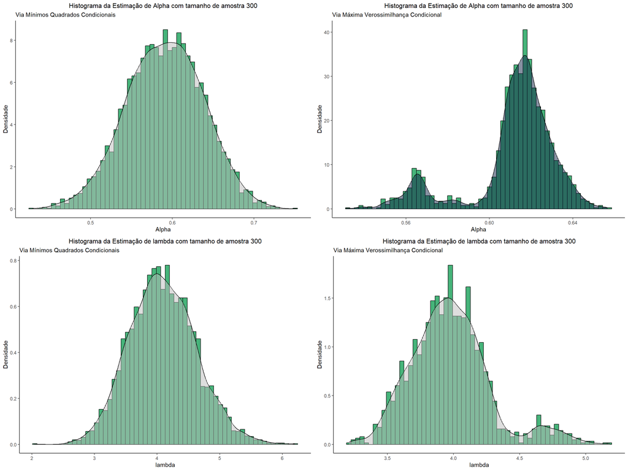

```r
gridExtra::grid.arrange(grafico_300_min_quad_alpha, grafico_300_max_vero_alpha, grafico_300_min_quad_lambda, grafico_300_max_vero_lambda, nrow = 2, ncol = 2)
```

### Amostra de tamanho 500

```r
resultados_geom_500 <- simulacao_monte_carlo(n_simulacoes = 5000, n_amostra = 500, alpha_verdadeiro = 0.6, mu_verdadeiro = 4, distribuicao = "geometrica")
```

```r
paste0("Com tamanho de amostra 500 e via mínimos quadrados condicionais, temos o seguinte alpha médio: ", round(resultados_geom_500$media_Minimos_Quadrados_condicionais[1], 4)," para o lambda Médio: ", round(resultados_geom_500$media_Minimos_Quadrados_condicionais[2], 4))
```

```
[1] "Com tamanho de amostra 500 e via mínimos quadrados condicionais, temos o seguinte alpha médio: 0.5941 para o lambda Médio: 4.0603"
```

```r
paste0("Com tamanho de amostra 500 e via Máxima Verossimilhança Condicional, temos o seguinte alpha médio: ",   round(resultados_geom_500$media_Maxima_verossimilhanca_condicional[1], 4)," para o lambda Médio: ", round(resultados_geom_500$media_Maxima_verossimilhanca_condicional[2], 4))
```

```
[1] "Com tamanho de amostra 500 e via Máxima Verossimilhança Condicional, temos o seguinte alpha médio: 0.6126 para o lambda Médio: 3.9803"
```

```r
paste0("Com tamanho de amostra 500 e via Mínimos Quadrados Condicionais, temos a variância do alpha: ",
       round(resultados_geom_500$variancia_Minimos_Quadrados_condicionais[1], 4), " e a variância para o lambda: ",
       round(resultados_geom_500$variancia_Minimos_Quadrados_condicionais[2], 4))
```

```
[1] "Com tamanho de amostra 500 e via Mínimos Quadrados Condicionais, temos a variância do alpha: 0.0014 e a variância para o lambda: 0.1753"
```

```r
paste0("Com tamanho de amostra 500 e via Máxima Verossimilhança Condicional, temos a variância do alpha: ",
       round(resultados_geom_500$variancia_Maxima_verossimilhanca_condicional[1], 4), " e a variância para o lambda: ",
       round(resultados_geom_500$variancia_Maxima_verossimilhanca_condicional[2], 4))
```

```
[1] "Com tamanho de amostra 500 e via Máxima Verossimilhança Condicional, temos a variância do alpha: 2e-04 e a variância para o lambda: 0.057"
```

```r
banco_geom_500_min_quad <- as.data.frame(resultados_geom_500[[5]])
banco_geom_500_max_vero <- as.data.frame(resultados_geom_500[[6]])
```

- Visualizando os resultados de Maneira Gráfica
- Através de um histograma, podemos analisar quais foram os resultados da estimação dos parâmetros.

```r
grafico_500_min_quad_lambda <- ggplot(banco_geom_500_min_quad) +
 aes(x = V2) +
 geom_histogram(aes(y = ..density..), bins = 60L, fill = "#46B47A", color = "black") +
 geom_density(
 alpha = 0.5, fill = "gray") +
 labs(x = "lambda", y = "Densidade", title = "Histograma da Estimação de lambda com tamanho de amostra 500",
      subtitle = "Via Mínimos Quadrados Condicionais") +
 theme_classic() +
 theme(plot.title = element_text(size = 12L, hjust = 0.5))
```

```r
grafico_500_min_quad_alpha <- ggplot(banco_geom_500_min_quad) +
 aes(x = V1) +
 geom_histogram(aes(y = ..density..), bins = 60L, fill = "#46B47A", color = "black") +
 geom_density(
 alpha = 0.5, fill = "gray") +
 labs(x = "Alpha", y = "Densidade", title = "Histograma da Estimação de Alpha com tamanho de amostra 500",
      subtitle = "Via Mínimos Quadrados Condicionais") +
 theme_classic() +
 theme(plot.title = element_text(size = 12L, hjust = 0.5))
```

```r
grafico_500_max_vero_lambda <- ggplot(banco_geom_500_max_vero) +
 aes(x = V2) +
 geom_histogram(aes(y = ..density..), bins = 60L, fill = "#46B47A", color = "black") +
 geom_density(
 alpha = 0.5, fill = "gray") +
 labs(x = "lambda", y = "Densidade", title = "Histograma da Estimação de lambda com tamanho de amostra 500",
      subtitle = "Via Máxima Verossimilhança Condicional") +
 theme_classic() +
 theme(plot.title = element_text(size = 12L, hjust = 0.5))
```

```r
grafico_500_max_vero_alpha <- ggplot(banco_geom_500_max_vero) +
 aes(x = V1) +
 geom_histogram(aes(y = ..density..), bins = 60L, fill = "#46B47A", color = "black") +
 geom_density(
 alpha = 0.5, fill = "gray") +
 labs(x = "Alpha", y = "Densidade", title = "Histograma da Estimação de Alpha com tamanho de amostra 500",
      subtitle = "Via Máxima Verossimilhança Condicional") +
 theme_classic() +
 theme(plot.title = element_text(size = 12L, hjust = 0.5))
```

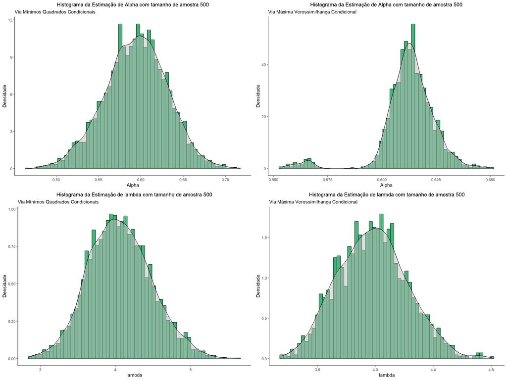

```r
gridExtra::grid.arrange(grafico_500_min_quad_alpha, grafico_500_max_vero_alpha, grafico_500_min_quad_lambda, grafico_500_max_vero_lambda, nrow = 2, ncol = 2)
```